# Linear Model: Facial Appearance and Election Outcomes

Quantitative Methods for Humanities

CUNEF Universidad, 2024

# Prelude

Before running this Rmarkdown notebook, ensure that the `rmarkdown` package is installed (`install.packages("rmarkdown")`). Additionally, load the necessary libraries and data sets:

```r
# You may need to install these packages... Uncomment to do so
# install.packages("devtools")
# devtools::install_github("kosukeimai/qss-package")
library(qss)
data("face", package = "qss")
```

# Introduction

Psychologists have conducted an experiment suggesting that judgments of candidates’ facial appearance, made in under a second, can predict election outcomes at rates better than chance.[^1] In this study, student participants were briefly shown black-and-white photographs of two congressional candidates (the ultimate winner and the runner-up). The photographs were displayed for under a second, and the participants were then asked to rate the candidates’ competence.

The experimenters used these competence ratings to gauge whether a rapid facial assessment could anticipate real-world election results. **The subjects surveyed were unfamiliar with each candidate’s political affiliation, policy positions, or incumbency status.** Their judgments, therefore, relied exclusively on the candidates’ facial impressions.

# The Data

The dataset (accessible in the Prelude section) contains 119 observations and 10 variables about election outcomes across different states and congressional sessions. The variables are:

- `year`: the year of the election.
- `state`: the state where the election occurred.
- `winner`: the name of the winning candidate.
- `loser`: the name of the runner-up candidate.
- `w.party`: the political party of the winning candidate.
- `l.party`: the political party of the runner-up candidate.
- `d.votes`: the number of votes received by the Democratic candidate.
- `r.votes`: the number of votes received by the Republican candidate.
- `d.comp`: a competence measure for the Democratic candidate.
- `r.comp`: a competence measure for the Republican candidate.

Below is a summary of the basic statistics for each variable.

```r
summary(face)
```

```
##       year         state              winner             loser
##  Min.   :2000   Length:119         Length:119         Length:119
##  1st Qu.:2002   Class :character   Class :character   Class :character
##  Median :2004   Mode  :character   Mode  :character   Mode  :character
##  Mean   :2003
##  3rd Qu.:2004
##  Max.   :2006
##    w.party            l.party              d.comp           r.comp
##  Length:119         Length:119         Min.   :0.0640   Min.   :0.1028
##  Class :character   Class :character   1st Qu.:0.3264   1st Qu.:0.3817
##  Mode  :character   Mode  :character   Median :0.5169   Median :0.4831
##                                        Mean   :0.4818   Mean   :0.5182
##                                        3rd Qu.:0.6183   3rd Qu.:0.6736
##                                        Max.   :0.8972   Max.   :0.9360
##     d.votes           r.votes
##  Min.   :  20466   Min.   :  64133
##  1st Qu.: 229213   1st Qu.: 246221
##  Median : 593302   Median : 678376
##  Mean   : 982428   Mean   : 902968
##  3rd Qu.:1337048   3rd Qu.:1190878
##  Max.   :5790154   Max.   :4080582
```

# Correlation and scatter plots

To explore how facial competence might relate to election outcomes, we can start by plotting competence scores against the vote differences. We define the *win margin* for the Democratic candidate as the difference in two-party vote shares (Democratic minus Republican). Two-party vote share is the fraction of votes going to each major party, ignoring votes for other parties.

```r
## two-party vote share for Democrats and Republicans
face$d.share <- face$d.votes / (face$d.votes + face$r.votes)
face$r.share <- face$r.votes / (face$d.votes + face$r.votes)
face$diff.share <- face$d.share - face$r.share
```

The plot shows a mild upward trend in the Democratic margin as the competence score for Democrats increases.

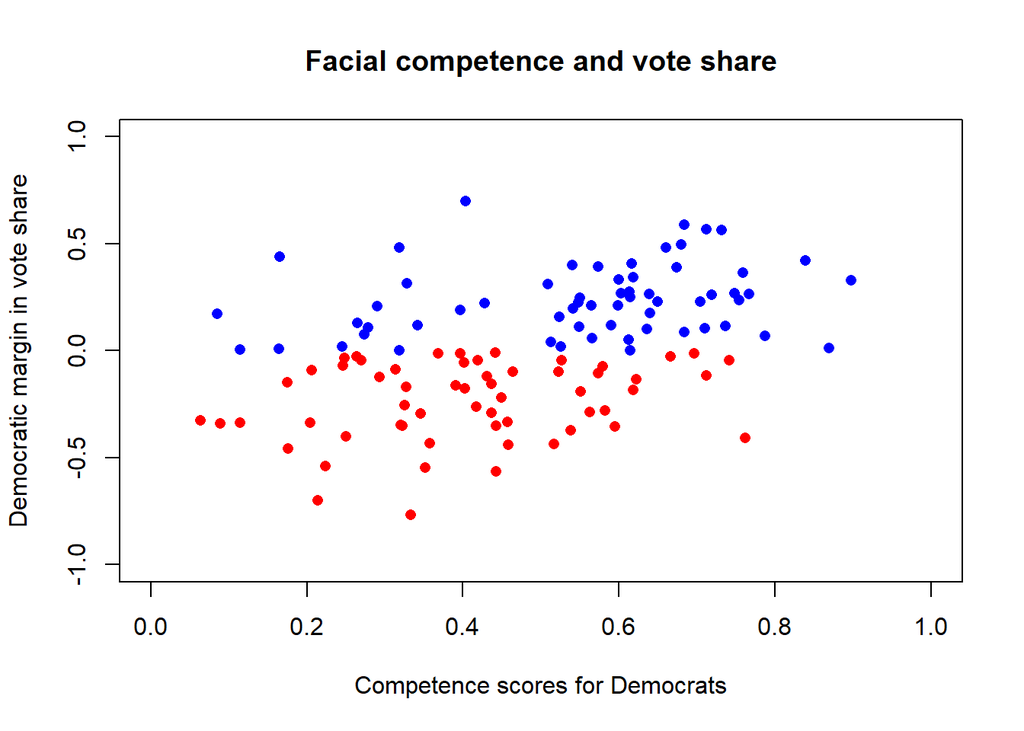

```r
plot(face$d.comp, face$diff.share, pch = 16,
     col = ifelse(face$w.party == "R", "red", "blue"),
     xlim = c(0, 1), ylim = c(-1, 1),
     xlab = "Competence scores for Democrats",
     ylab = "Democratic margin in vote share",
     main = "Facial competence and vote share")
```

Let us know compute the correlation coefficient between the variables `d.comp` and `diff.share` of our dataset.

```r
cor(face$d.comp, face$diff.share)
```

```
## [1] 0.4327743
```

The resulting correlation of around $0.4$ indicates a moderately positive relationship: in races where the Democratic candidate was considered more competent by the experimental subjects (who had no prior familiarity with the candidates), the Democratic margin of victory tended to be larger.

# Linear Regression

We can fit a linear regression model in R using `lm()`. This function takes a **formula** of the form `Y ~ X` as the main argument, indicating the outcome variable as `Y` and the predictor as `X`, taken from a data frame specified as the `data` argument. By default, the regression includes an intercept term. In our case, `diff.share` is the outcome variable and `d.comp` is the predictor.

```r
fit <- lm(diff.share ~ d.comp, data = face) # fit the model
fit
```

```
##
## Call:
## lm(formula = diff.share ~ d.comp, data = face)
##
## Coefficients:
## (Intercept)       d.comp
##     -0.3122       0.6604
```

The output shows that the estimated intercept is −0.3122 whereas the estimated slope is 0.6604. That is, when no experimental subject thinks a Democratic candidate is more competent than a Republican counterpart, the predicted Democratic margin of two-party vote share is approximately −31.2 percentage points. If the perceived competence score increases by 10 percentage points, then the outcome variable is predicted to increase on average by 6.6 (= 0.6604 × 10) percentage points.

There is an alternative way of fitting the same model without the data argument. This requires specifying the entire names of objects for the outcome variable and the predictor as follows.

```r
lm(face$diff.share ~ face$d.comp) # fit the model without specifying the data argument
```

```
##
## Call:
## lm(formula = face$diff.share ~ face$d.comp)
##
## Coefficients:
## (Intercept)  face$d.comp
##     -0.3122       0.6604
```

In general, this is not recommended because it unnecessarily complicates the syntax and may cause confusion. However, it may be useful when the variables we wish to use for regression exist as separate objects in the workspace.

We can also extract the coefficients and fitted values directly by using the functions `coef()` and `fitted()` functions, respectively.

```r
coef(fit) # get estimated coefficients
```

```
## (Intercept)      d.comp
##  -0.3122259   0.6603815
```

```r
head(fitted(fit)) # get fitted or predicted values
```

```
##           1           2           3           4           5           6
##  0.06060411 -0.08643340  0.09217061  0.04539236  0.13698690 -0.10057206
```

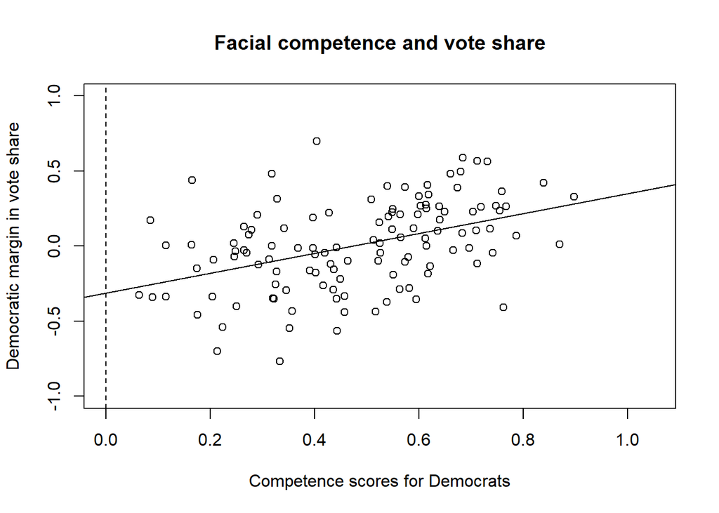

```r
plot(face$d.comp, face$diff.share, xlim = c(0, 1.05), ylim = c(-1,1),
    xlab = "Competence scores for Democrats",
    ylab = "Democratic margin in vote share",
    main = "Facial competence and vote share")
abline(fit) # add regression line
abline(v = 0, lty = "dashed")
```